# Lecture 09: ANOVA Recap and Factorial Designs

A potent tool

Dr. Gordon Wright

g.wright@gold.ac.uk

Mon 02 Dec, 2024

## Situating ANOVA Within the GLM

## What is the General Linear Model (GLM)?

- **GLM** is a framework that describes a broad set of statistical models.
- Includes techniques like:
  - ANOVA (Analysis of Variance)
  - Multiple Regression
  - ANCOVA (Analysis of Covariance)
  - MANOVA (Multivariate ANOVA)

## What is the General Linear Model (GLM)?

- Unified by the equation:

$$Y = X\beta + \epsilon$$

## Visualizing the General Linear Model (GLM)

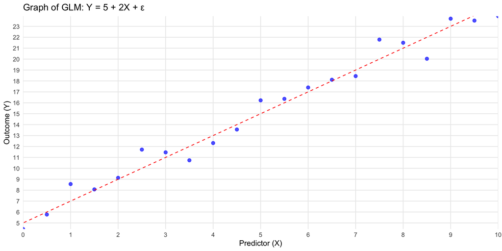

Figure 1: Graphical Representation of the General Linear Model with Intercept(5) and Slope(2).

## Key Elements of the GLM Equation 1/2

1. **Outcome Variable** (*Y*):
   - The dependent variable being predicted or explained.
   - Usually continuous in both regression and ANOVA models.
2. **Predictors** (*X*):
   - Independent variables in regression (e.g., continuous variables).
   - Grouping variables in ANOVA (e.g., categorical variables).

## Key Elements of the GLM Equation 1/2

3. **Coefficients** (*β*):
   - Represent the estimated weights or effects of predictors (*X*) on the outcome (*Y*).
4. **Error Term** (*ε*):
   - Captures the variation in *Y* that is not explained by the predictors.

## ANOVA as a Special Case of GLM

- ANOVA compares means across groups by partitioning variance:
  - **Total Variance = Variance Between Groups + Variance Within Groups**
- In GLM terms:
  - **X**: Encodes group membership using dummy variables.
  - **β**: Represents group mean effects.
  - **ε**: Residual error capturing unexplained variance.

## Extending to Factorial Designs: Main Effects

- Factorial designs include multiple predictors (e.g., **A** and **B**).
- Each predictor contributes to the outcome variable (**Y**) through:
  - **Main Effects**:
    - Effect of **A** (e.g., differences across levels of factor A).
    - Effect of **B** (e.g., differences across levels of factor B).
  - **Residual Error**: Variation unexplained by predictors.

### How They Are Related

- **ANOVA**:
  - Focuses on group differences (categorical predictors).
  - Example: Comparing means of 3 groups.
- **Multiple Regression**:
  - Allows continuous and categorical predictors.
  - Example: Predicting an outcome using test scores and group membership.
- **Connection**:
  - ANOVA is a regression model with categorical predictors encoded as dummy variables.

## Example: One-Way ANOVA as Regression

- Regression model for a one-way ANOVA:

**Y = β₀ + β₁X₁ + β₂X₂ + ε**

### Components:

- **X₁, X₂**: Dummy variables for groups.
- **β₁**: Difference between group 1 and the reference group.
- **β₂**: Difference between group 2 and the reference group.

## Visualizing the Relationship

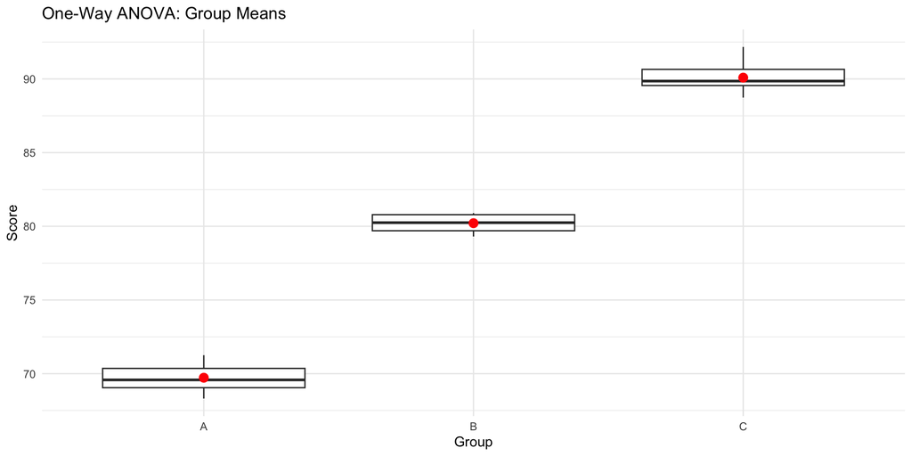

Figure 2: ANOVA as regression: Group means represented by dummy variables.

## Key Takeaways

### GLM Framework

- ANOVA and Regression are special cases of GLM.
- Both share the same foundation:
- **Y = Xβ + ε**:
  - Represents the General Linear Model (GLM).
  - (Y): Outcome variable (dependent variable).
  - (X): Predictors (independent variables).
  - (β): Coefficients for predictors.
  - (ε): Residual error term.

### Practical Differences

- ANOVA emphasizes group comparisons.
- Regression allows for both continuous and categorical predictors.

## Recap on Factorial Designs

## What Are Factorial Designs?

- Factorial designs involve multiple independent variables (IVs).
- Common in psychology research for testing complex interactions.
- Goal: To interpret **main effects** and **interactions**.

## Why Focus on 2x2 Designs this year?

- Simplest factorial design with:
  - 2 Independent Variables (IVs).
  - Each IV has 2 levels.
- Patterns in data can show:
  - Main Effects: Influence of each IV independently.
  - Interactions: Combined influence of IVs.

## Understanding the 8 Possible Patterns

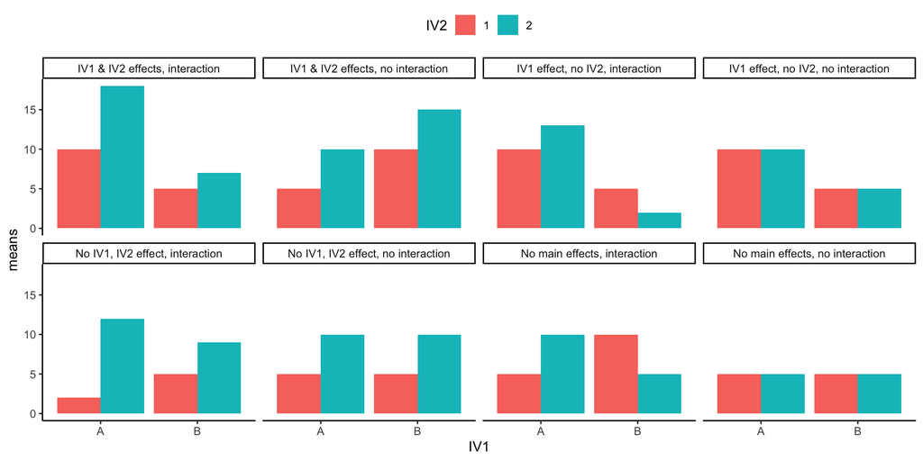

Figure 3: Bar graphs: 8 possible outcomes in 2x2 design.

## Exploring Main Effects and Interactions

## Interpreting Main Effects

- Main effects represent the **consistent influence** of an IV.
- Example: **Coffee and wakefulness**:
  - More coffee = Higher alertness, regardless of location.

## Interaction Effects

- Interaction occurs when one IV’s effect depends on the level of another.
- Example: Coffee may affect wakefulness differently **in the morning** vs. **at night**.

## Best Practices for Factorial Designs

- Keep designs **simple**: Fewer IVs and levels make interpretation easier.
- Ensure **sufficient data** for all combinations of IV levels.
- Always visualize data before analysis to understand patterns.

## Summary

- **2x2 designs** are foundational in understanding factorial experiments.
- Interactions complicate main effects but reveal critical relationships.
- Use clear visualizations to enhance interpretation.

## Citation and Acknowledgments

**Note**

Crump, M. J. C., Navarro, D. J., & Suzuki, J. (2019, June 5). *Answering Questions with Data (Textbook)*: Introductory Statistics for Psychology Students. https://doi.org/10.17605/OSF.IO/JZE52

Research Methods Lecture 09